# Quantiles Simulation Exercise

In this notebook we’ll separately simulate data from light and heavy tailed distributions, compute the quantiles of the data and compare against those of a Normal.

To begin, a uniform distribution is a nice example of a light-tailed distribution, since its tails are suddenly truncated at its boundaries. A uniform distribution puts equal probability over all possible values that a random variable can take. It can be both discrete or continuous, but we will only consider the continuous case. Specifically, $X \sim U(a,b)$ means that $X$ can take any value between the numbers $a$ and $b$ with equal probability. For the standard case where $a=0$ and $b=1$, the density and cumulative distribution functions look like:

```r
a = 0
b = 1
xGrid = seq(a,b,length=10000)
pdfVals = dunif(xGrid,a,b)
cdfVals = punif(xGrid,a,b)
par(mfrow=c(1,2))
plot(xGrid,pdfVals,type="l",ylim=c(0,1.2))
segments(0,0,0,1,lty=3)
```

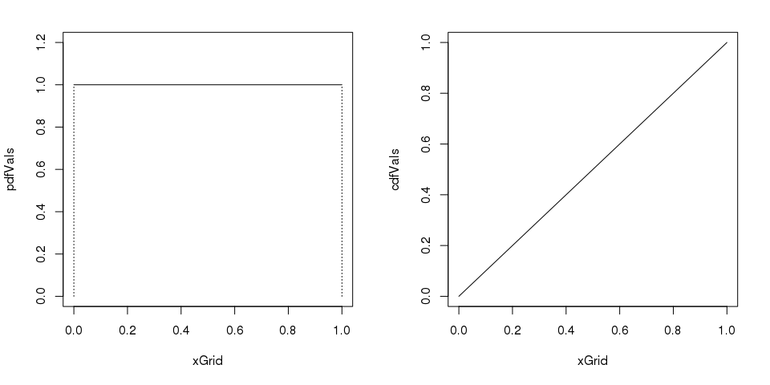

```r
segments(1,0,1,1,lty=3)
plot(xGrid,cdfVals,type="l")
```

It can be shown that if $X \sim U(a,b)$, then $E[X] = \frac{1}{2}(a+b)$ and $Var(X) = \frac{1}{12}(b-a)^2$. Let’s set $a=0$ and $b=2$ and create a plot that compares the true $U(0,2)$ with the true $N(\mu,\sigma)$ density where $\mu = \frac{1}{2}(a+b) = 1$ and $\sigma = \sqrt{\frac{1}{12}(b-a)^2} = \frac{1}{\sqrt{3}}$.

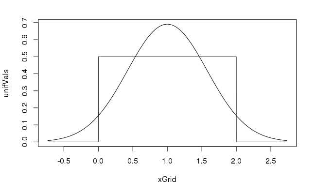

```r
a = 0
b = 2
mu = 0.5*(a+b)
sig = sqrt(((b-a)^2)/12)
xGrid = seq(mu-3*sig,mu+3*sig,length=10000)
unifVals = dunif(xGrid,a,b)
normVals = dnorm(xGrid,mu,sig)
yMax = max(max(unifVals),max(normVals))
plot(xGrid,unifVals,type="l",ylim=c(0,yMax))
lines(xGrid,normVals,type="l")
```

The following code will simulate from a $U(0,2)$, compute the quantiles and compare with those of a standard Normal.

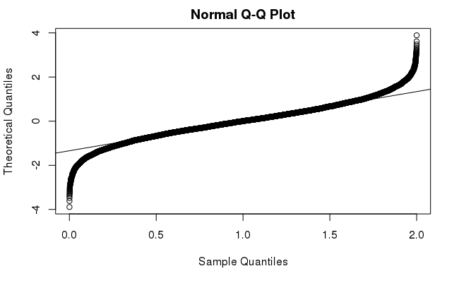

```r
nSim = 10000
a = 0
b = 2
xSample = runif(nSim,a,b)
qqnorm(xSample,datax=TRUE)
qqline(xSample,datax=TRUE)
```

With the data quantiles on the x-axis, the plot above depicts the signature of a light-tailed distribution. We can recreate this plot without the `qqnorm` function, by “manually” computing the quantiles of the best fit Normal and the standard Normal, and plotting the quantiles of the data againt the Normal quantiles we compute.

```r
qGrid = (1:(nSim-1))/nSim
dataQuantiles = quantile(xSample,qGrid)
normQuantiles = qnorm(qGrid,mean(xSample),sd(xSample))
stdNormQuantiles = qnorm(qGrid,0,1)
par(mfrow=c(1,2))
plot(dataQuantiles,normQuantiles)
abline(0,1)
```

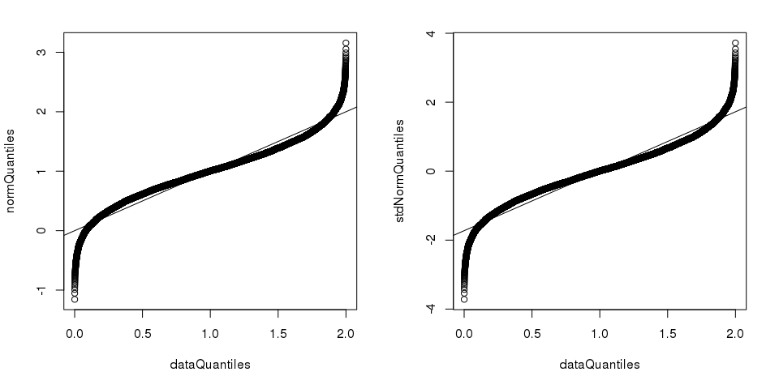

```r
plot(dataQuantiles,stdNormQuantiles)
abline(-mean(xSample)/sd(xSample),1/sd(xSample))
```

In the first panel I have plotted the data quantiles against those of a $N(\mu,\sigma)$ where $\mu$ and $\sigma$ are set equal to the sample mean and sample standard deviation of the data. In this case the sample mean and standard deviation are 1.0006563 and 0.5798653, respectively. The line in that plot is simply the 45 degree line (intercept 0, slope 1). In the second panel I have potted the quantiles of the data against those of the standard Normal. In this case, the standard Normal quantiles are the same as the quantiles in the first panel, after standardizing:
$$\begin{align}
Z & = \frac{X-\mu}{\sigma} = \frac{X}{\sigma} - \frac{\mu}{\sigma},
\end{align}$$

which is slope-intercept form with a slope of $\frac{1}{\sigma}$ and an intercept of $-\frac{\mu}{\sigma}$. This is the appropriate line to draw on the second panel. Notice, however, that the two lines in the plot above do not fit the cenral region of the quantiles like the `qqline` function in the first plot above. This is because `qqline` fits a line through the 0.25 and 0.75 quantiles. We can do the same:

```r
qGrid = (1:(nSim-1))/nSim
dataQuantiles = quantile(xSample,qGrid)
normQuantiles = qnorm(qGrid,mean(xSample),sd(xSample))
stdNormQuantiles = qnorm(qGrid,0,1)
par(mfrow=c(1,2))
plot(dataQuantiles,normQuantiles)
iqrNorm = qnorm(c(0.25,0.75),mean(xSample),sd(xSample))
iqrData = quantile(xSample,c(0.25,0.75))
iqrSlope = diff(iqrNorm)/diff(iqrData)
iqrInt = iqrNorm[1] - iqrSlope*iqrData[1]
abline(iqrInt,iqrSlope,lty=3)
```

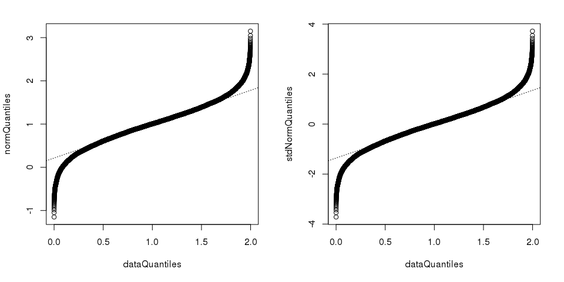

```r
plot(dataQuantiles,stdNormQuantiles)
iqrNorm = qnorm(c(0.25,0.75),0,1)
iqrData = quantile(xSample,c(0.25,0.75))
iqrSlope = diff(iqrNorm)/diff(iqrData)
iqrInt = iqrNorm[1] - iqrSlope*iqrData[1]
abline(iqrInt,iqrSlope,lty=3)
```

Let’s now consider a heavy-tailed distribution: $X \sim t(\nu)$, where $t$ denotes the $t$-distribution and $\nu$ is the degrees of freedom parameter. It can be shown that for $\nu > 2$ if $X \sim t(\nu)$, then $E[X]=0$ and $Var(X) = \frac{\nu}{\nu-2}$. Assuming that $X \sim t(4)$, we will begin by comparing the theoretical distribution for $X$ (a $t$ with degrees of freedom equal to 4) with a theoretical Normal with mean 0 and standard deviation $\sqrt{\frac{\nu}{\nu-2}} = \sqrt{2}$.

```r
nu = 4
mu = 0
sig = sqrt(nu/(nu-2))
xGrid = seq(mu-4*sig,mu+4*sig,length=10000)
tVals = dt(xGrid,nu)
normVals = dnorm(xGrid,mu,sig)
yMax = max(max(tVals),max(normVals))
plot(xGrid,tVals,type="l",ylim=c(0,yMax))
lines(xGrid,normVals,type="l",lty=2)
```

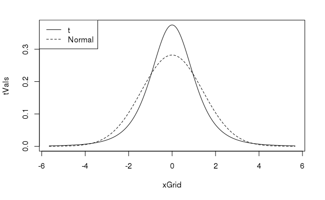

```r
legend("topleft",legend = c("t","Normal"),lty=c(1,2))
```

If we look closely at the tail regions, we can see that the $t$ has much more probability mass:

```r
par(mfrow=c(1,2))
plot(xGrid,tVals,type="l",xlim=c(-5,-4),ylim=c(0,yMax/40))
lines(xGrid,normVals,type="l",lty=2)
```

```r
legend("topleft",legend = c("t","Normal"),lty=c(1,2))
plot(xGrid,tVals,type="l",xlim=c(4,5),ylim=c(0,yMax/40))
```

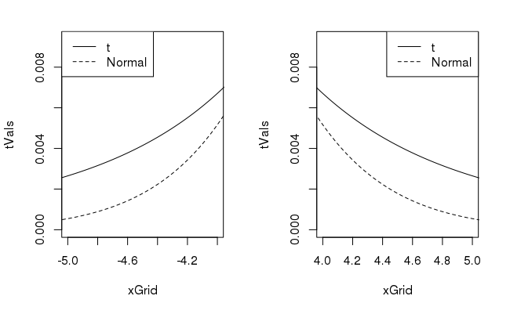

```r
lines(xGrid,normVals,type="l",lty=2)
legend("topright",legend = c("t","Normal"),lty=c(1,2))
```

We can now simulate from the $t(4)$ distribution and plot the quantiles against those of the standard Normal.

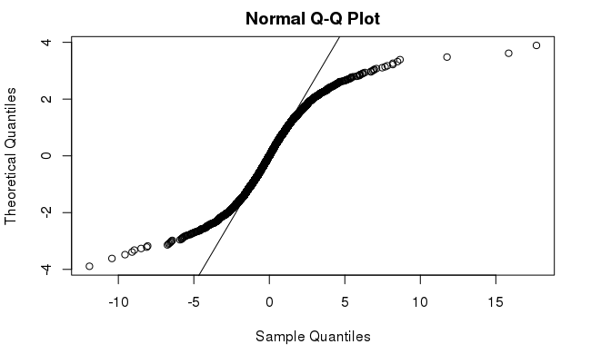

```r
nSim = 10000
nu = 4
xSample = rt(nSim,nu)
qqnorm(xSample,datax=TRUE)
qqline(xSample,datax=TRUE)
```

With the data quantiles on the x-axis, the plot above depicts the signature of a heavy-tailed distribution.